# R Análisis Numéricos Eddy Herrera Daza

##Ejercicios

```r
library(pracma)
library(Matrix)
```

1. Para el siguiente ejercico, instale el paquete “pracma”
1. Revise las siguientes funciones con la matriz del ejercicio 2
2. Evalue la matriz de transición para el método $\textbf{SOR}$

```r
D1<-eye(4) #Diagonal de la matriz con 1
D2<-ones(4) #Matriz llenas de unos
D3<-zeros(4) #Matriz llena de ceros

A = matrix(c(-8.1, -7, 6.123, -2, -1, 4,
-3, -1, 0, -1, -5, 0.6,
-1, 0.33, 6, 1/2), nrow=4, byrow=TRUE)

metodoSOR<-function(A,n,w){
U<-A
L<-A
D<- (A*eye(4)) #Diagonal de A
L[lower.tri(L, diag = FALSE) ]<-0 #triangular inferior
U[upper.tri(U, diag = FALSE) ]<-0 #triangular superior
aux<-(D-(w*L))
aux1<-inv(aux)
aux2<-((1-w)*D)+(U*w)
combinacion<-aux1*aux2
combinacion
}
#valor de w debe estar entre 0-2 pra que la funcion pueda converger
metodoSOR(A,4,0.5)
```

```
     [,1] [,2] [,3] [,4]
[1,]    2    0    0    0
[2,]    0    2    0    0
[3,]    0    0    2    0
[4,]    0    0    0    2
```

2. Dada la siguiente matriz, utilice las funciones del paquete para descomponer la matriz $A=L+D+U$ (Jacobi)

```
     [,1]  [,2]   [,3] [,4]
[1,] -8.1 -7.00  6.123 -2.0
[2,] -1.0  4.00 -3.000 -1.0
[3,]  0.0 -1.00 -5.000  0.6
[4,] -1.0  0.33  6.000  0.5
```

2. Utilice la función itersolve(A, b, tol , method = “Gauss-Seidel”) y solucionar el sistema asociado a la matriz $A$ con $b=[1.45,3,5.12,-4]^{t}$ con una tolerancia de $1e^-9$

```r
A = matrix(c(-8.1, -7, 6.123, -2, -1, 4,
              -3, -1, 0, -1, -5, 0.6,
              -1, 0.33, 6, 1/2), nrow=4, byrow=TRUE)
b <- matrix(c(1.45,3,5.12,-4),nrow=4,ncol=1)

itersolve(A, b, tol = 1e-9, method = "Gauss-Seidel")
```

```
$x
[1] -3.696138e+196  2.853479e+196  1.611118e+196 -2.860899e+197

$iter
[1] 1000

$method
[1] "Gauss-Seidel"
```

3. Genere 5 iteraciones del método de Jacobi, calcular error relativo para cada iteracion

```r
itersolve(A, b, x0 = 1:4, nmax = 5, tol = 1e-9, method = "Jacobi")
```

```
$x
[1]  -12.167413    1.392056   -7.628979 -200.531199

$iter
[1] 5

$method
[1] "Jacobi"
```

3. Sea el sistema $AX=b$
1. Implemente una función en R para que evalue las raíces del polinomio característico asociado a la matriz $A$

```r
ValProp <- function(A){
  Polinomio <- function(lambda) {
    y = A
    diag(y) = diag(A) - lambda
    return(det(y))
  }
    FunProp <- function(lambda){
    sapply(lambda, Polinomio)
  }
  uniroot.all(FunProp, c(-10, 10))
}
ValProp(A)
```

```
[1] -8.864279 -5.833187  1.286718  4.810733
```

2. Use el teorema de convergencia para determinar cuál método iterativo es más favorable.

```r
  itersolve(A, b, tol = 1e-9, method = "Gauss-Seidel")
```

```
$x
[1] -3.696138e+196  2.853479e+196  1.611118e+196 -2.860899e+197

$iter
[1] 1000

$method
[1] "Gauss-Seidel"
```

```r
  itersolve(A, b, x0 = 1:4,  tol = 1e-9, method = "Jacobi")
```

```
$x
[1] -2.838728e+164  3.525832e+164  1.325663e+164 -7.510601e+164

$iter
[1] 1000

$method
[1] "Jacobi"
```

3. Evalue la matriz de transición para cada caso y en el caso del método de relajación determine el valor óptimo de $\omega$

```r
 A = matrix(c(4, -1, -1, -1, -1, 4,
             -1, -1, -1, -1, 4, -1,
             -1, -1, -1, 4), nrow=4, byrow=TRUE)
TransicionJac<-function(A,n){
  D<- (A*eye(n, m = n)) #Diagonal de A
  L<-A
  L[lower.tri(L, diag = FALSE) ]<-0 #triangular inferior

  auxI<-inv(D)
  U<-A
  U[upper.tri(U, diag = FALSE) ]<-0#triangular superior

  Tra<-auxI*(L+U)
  Tra
}
metodoSOR<-function(A,n,w){
U<-A
L<-A
D<- (A*eye(4)) #Diagonal de A
L[lower.tri(L, diag = FALSE) ]<-0 #triangular inferior
U[upper.tri(U, diag = FALSE) ]<-0 #triangular superior
aux<-(D-(w*L))
aux1<-inv(aux)
aux2<-((1-w)*D)+(U*w)
combinacion<-aux1*aux2
combinacion
}
#valor de w debe estar entre 0-2 pra que la funcion pueda converger
TransicionJac(A,4)
```

```
     [,1] [,2] [,3] [,4]
[1,]    2    0    0    0
[2,]    0    2    0    0
[3,]    0    0    2    0
[4,]    0    0    0    2
```

```r
metodoSOR(A,4,0.5)
```

```
     [,1] [,2] [,3] [,4]
[1,]    2    0    0    0
[2,]    0    2    0    0
[3,]    0    0    2    0
[4,]    0    0    0    2
```

4. Teniendo en cuenta lo anterio resolver el sistema

```r
A = matrix(c(4, -1, -1, -1, -1, 4,
-1, -1, -1, -1, 4, -1,
-1, -1, -1, 4), nrow=4, byrow=TRUE)
A
```

```
     [,1] [,2] [,3] [,4]
[1,]    4   -1   -1   -1
[2,]   -1    4   -1   -1
[3,]   -1   -1    4   -1
[4,]   -1   -1   -1    4
```

```r
b = c(1, 5, 1.5,-2.33)
b
```

```
[1]  1.00  5.00  1.50 -2.33
```

```r
itersolve(A, b, tol = 1e-5, method = "Gauss-Seidel")
```

```
$x
[1] 1.2339811 2.0339836 1.3339858 0.5679876

$iter
[1] 20

$method
[1] "Gauss-Seidel"
```

```r
itersolve(A, b, x0 = 1:4,  tol = 1e-5, method = "Jacobi")
```

```
$x
[1] 1.2340682 2.0340682 1.3340682 0.5680682

$iter
[1] 34

$method
[1] "Jacobi"
```

```r
solucion<- solve(A,b)
A = matrix(c(4, -1, -1, -1, -1, 4,
             -1, -1, -1, -1, 4, -1,
             -1, -1, -1, 4), nrow=4, byrow=TRUE)
A
b = c(1, 5, 1.5,-2.33)
solve(A,b)
```

[output not shown]

1. Pruebe el siguiente algoritmo con una matriz $A_{3}$, modifiquelo para quue $a_{ii}=0$ para todo $i$

```r
mat = matrix(
  c(
    2.6,0.3,2.4,
    7.7,0.4,4.7,
    5.1,9.9,9.5,
    6.0,7.0,8.5
  ), nrow= 3 , byrow = TRUE
)
tril1 <- function(M, k = 0) {
  #mat[upper.tri(mat, diag = TRUE)] <- 0
  #mat[lower.tri(mat, diag = FALSE)] <- 0
  if (k == 0)
  {
    M[upper.tri(M, diag = FALSE)] <- 0
  }
  else
  {
    M[col(M) >= row(M) + k + 1] <- 0
  }
  return(M)
}
tril1(mat,0)
```

```
     [,1] [,2] [,3] [,4]
[1,]  2.6  0.0    0    0
[2,]  0.4  4.7    0    0
[3,]  9.5  6.0    7    0
```

2. Implemente una función en R para que dada una matriz $A$ se obtenga una matriz diagonal $D$ donde en la diagonal estan los mismo elementos de A

```r
diagonal<-function(A,n){
D<-(A*eye(n, m = n))
D
}
diagonal(A,4)
```

```
     [,1] [,2] [,3] [,4]
[1,]    4    0    0    0
[2,]    0    4    0    0
[3,]    0    0    4    0
[4,]    0    0    0    4
```

4. Cree una función que cuente el número de multiplicaciones en el método directo de Gauss Jordan, para resolver un sistema de $n$ ecuaciones y pruebelo para $n=5$

```r
Gauss_Jordan = function(A, b)
{
  n = nrow(A)
  Ab = cbind(A,b)
  mult <- 0
  for (k in 1:(n-1))
  {
    if(Ab[k,k]==0)
    {
      fila = which(Ab[k, ]!=0)[1]
      Ab[c(k, fila),  ] = Ab[c(fila, k),  ]
      mult <- mult +1
    }
    for (i in (k+1):n)
    {
      Ab[i, ] = Ab[i, ] - Ab[i, k]/Ab[k,k]*Ab[k, ]
      mult <- mult +1
    }
  }
  x = rep(NA, times=n)
  x[n] = Ab[n, n+1]/Ab[n,n]
  for(i in(n-1):1)
  {
    x[i]= (Ab[i, n+1]-sum(Ab[i,(i+1):n]*x[(i+1):n]))/Ab[i,i]
    mult <- mult +1
  }

  cat("multiplicaciones : ",mult,"\n")

  return(x)
}
C = matrix(c( 0,  2,  3, 3,
              -5, -4,  1, 4,
              0,  0,  0, 3,
              -4, -7, -8, 9), nrow=4, byrow=TRUE)
b = c(1,0,0,0)
Gauss_Jordan(C,b)
```

[output not shown]

5. Dado el siguiente sistema:

```r
rm(list=ls())
alpha <- 5
beta  <- 4
B = matrix(c(   2   ,0,-1   ,
                beta,2,-1   ,
                -1  ,1,alpha), nrow=3, byrow= TRUE)
b <- c(1,2,1)
solve(B,b)
```

```
[1]  0.6875 -0.1875  0.3750
```

2. Genere una tabla que tenga 10 iteraciones del método de Jacobi con vector inicial $x_{0}=[1,2,3]^t$

```r
rm(list=ls())
alpha <- 5
beta  <- 3
B = matrix(c(   2   ,0,-1   ,
                beta,2,-1   ,
                -1  ,1,alpha), nrow=3, byrow= TRUE)
b <- c(1,2,3)
resp <- solve(B,b)
for( i in c(1:10))
{
  resp <- solve(B,resp)
  print(resp)
}
```

```
[1]  0.6574394 -0.7404844  0.4325260
[1]  0.5198453 -0.9588846  0.3822512
[1]  0.4377462 -0.9582380  0.3556471
[1]  0.3814553 -0.8887198  0.3251644
[1]  0.3373563 -0.8037657  0.2932573
[1]  0.3000706 -0.7205963  0.2627848
[1]  0.2674672 -0.6440670  0.2348638
[1]  0.2385843 -0.5750593  0.2097015
[1]  0.2128759 -0.5132597  0.1871674
[1]  0.1899547 -0.4580451  0.1670334
```

```r
rm(list=ls())
jacobi<-function(a,ciclos)
{
  n<-nrow(a)
  id <- matrix(0, n, n)
  diag(id) <- 1
  Q<-id
  for (k in 1:ciclos) {
    for ( i in 1:(n-1)) {
      for ( j in (i+1):n) {
        control <- 10^(-k)
        if( abs(a[i,j]) > control)
        {
          #print(c(a[i,j],control))
          angulo <- 0.5*atan(2*a[i,j]/(a[i,i] - a[j,j]))
          c<-cos(angulo)
          s<-sin(angulo)
          p<-id
          p[i,i]<-c
          p[j,j]<-c
          p[i,j]<- s
          p[j,i]<- s
          Q <- Q%*%p
          a<-t(p)%*%a%*%p
          a[i,j]<-0
          a[j,i]<-0
        }
      }
    }
    print(a)
  }

  cat("\n")
  cat("\n")
  cat("\n")
  #return(list(raices=diag(a),vectores=Q,estado=a))
}
alpha <- 5
beta  <- 3
B = matrix(c(2,0,-1,1,beta,2,-1,2,-1,1,alpha,1,0,0,0,0), ncol=4, byrow= TRUE)
print(B)
```

```
     [,1] [,2] [,3] [,4]
[1,]    2    0   -1    1
[2,]    3    2   -1    2
[3,]   -1    1    5    1
[4,]    0    0    0    0
```

```r
jacobi(B,10)
```

```
         [,1]      [,2]        [,3]        [,4]
[1,] 1.841474 0.1970787  0.08863812  0.13753063
[2,] 2.475227 3.0744109 -0.05674264 -0.03657048
[3,] 1.603364 1.2107307  4.44388090  0.00000000
[4,] 2.043200 0.7803126  0.00000000  3.89709398
             [,1]          [,2]         [,3]         [,4]
[1,] 1.3111648464 -0.0562334022  0.001238641 -0.002937606
[2,] 0.0055010564  2.6994918471 -0.002243650  0.000000000
[3,] 0.0004772806 -0.0003562891  4.424640393 -0.006820298
[4,] 0.0002873726  0.0000000000 -0.042949279  3.791160863
              [,1]          [,2]          [,3]          [,4]
[1,]  1.311383e+00  7.341120e-08 -5.079057e-05  5.466934e-07
[2,]  6.568892e-07  2.695177e+00  1.370518e-06 -1.273281e-04
[3,] -8.063369e-06  4.608598e-07  4.425096e+00  0.000000e+00
[4,]  8.679152e-08 -4.281619e-05  0.000000e+00  3.791763e+00
```

[output cut: 35 more lines]

6. Instalar el paquete Matrix y descomponga la matriz $A$ (del punto dos) de la forma $LU$ y la factorizarla como $A=QR$

```r
Descomponer<-function(nada){

  A <- matrix(c(-8.1, -7.00 , 6.123, -2.0,-1.0 , 4.00, -3.000, -1.0, 0.0, -1.00, -5.000,  0.6, -1.0,  0.33,  6.000,  0.5),nrow=4,ncol=4)
  D<- diag(x=1,nrow =4 ,ncol=4, names = TRUE)
  L<- lower.tri(A, diag = FALSE)
  U<- upper.tri(A, diag = FALSE)
  R<-L+U

  R1<- (1/det(R)*t(R))
  Q<-A %*% R1
  cat("A = QR:", "\n")
  cat(Q %*% R, "\n")
}
Descomponer(0)
```

[output not shown]

1. Determinar numéricamente la intersección entre la circunferencia $x^2 + y^2 = 1$ y la recta $y = x$. Usamos una aproximación inicial $(1,1)$. Utilice el pauqte BB y la función BBsolve() del paquete,grafique la solución

```r
inter=function(x){
  n=length(x)
  f=rep(NA,n)
  f[1]=+x[1]^2+x[2]^2-1
  t=2:(n-1)
  f[2]=x[1]-x[2]
  f
}
# Ecuaciones a graficar
f1=function(x){
  sqrt(1-x^2)
}

f2=function(x){
  -sqrt(1-x^2)
}
f3=function(x){
  x
}
# Se encuentra la solución del sistema de ecuaciones no lineales
sol=BBsolve(par=c(1,1),fn=inter)
```

```
  Successful convergence.
```

```r
cat("Solución (inicial de (1,1)):\n",sol[[1]],"\n")
```

```
Solución (inicial de (1,1)):
 0.7071068 0.7071068
```

```r
sol2=BBsolve(par=c(-1,1),fn=inter)
```

```
  Successful convergence.
```

```r
cat("Solución (inicial de (-1,1)):\n",sol2[[1]],"\n")
```

```
Solución (inicial de (-1,1)):
 -0.7071068 -0.7071067
```

```r
# Se grafican ecuaciones y puntos de intersección
x=seq(-1,1,0.0001)
plot(x,f3(x),type="l",col="red")
lines(x,f1(x),type="l",col="black")
```

```r
lines(x,f2(x),type="l",col="black")
abline(h=0,col="blue")
```

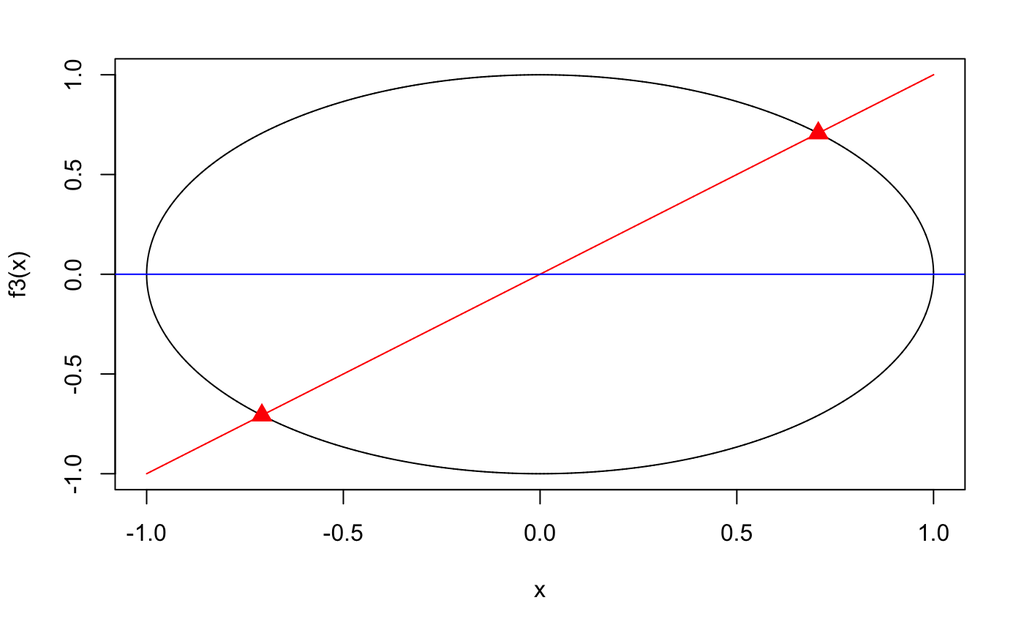

```r
points(rbind(c(sqrt(2)/2,sqrt(2)/2)),pch=17,cex=1.5,col="red")
points(rbind(c(-sqrt(2)/2,-sqrt(2)/2)),pch=17,cex=1.5,col="red")
```

b Analizar y comentar el siguinte código

```r
trigexp = function(x) {
  n = length(x) # longitud de vector x
  F = rep(NA, n) # F es una replica de un vector de tamaño n
  F[1] = 3*x[1]^2+2*x[2]-5+sin(x[1]-x[2])*sin(x[1]+x[2])
  tn1 = 2:(n-1)
  F[tn1]= -x[tn1-1]*exp(x[tn1-1]-x[tn1])+x[tn1]*(4+3*x[tn1]^2)+2*x[tn1+1]+sin(x[tn1]-x[tn1+1])*sin(x[tn1]+x[tn1+1])-8
  F[n] = -x[n-1]*exp(x[n-1]-x[n])+4*x[n]-3
  F
}
n = 10000
p0 = runif(n) # n initial random starting guesses
sol = BBsolve(par=p0, fn=trigexp) #intenta resolver la matriz F usando numeros entre
#0 y 10000 como posibles soluciones al sistema de ecuaciones nolineal fn
sol$par
```

[output not shown]

8. Demuestre y realice varias pruebas que la matriz de transición por el método de Gauss-Seidel esta dada por $T=(-D^{-1}U)(I+LD^{-1})^{-1}$
9. Punto 1 propuesto en clase

```r
repeat{
  a=sample(18:20,36,replace=T)
    dim(a)=c(6,6)
    a
    if(norm(a)*norm(solve(a)){
      norm(a)*norm(solve(a))
      break
    }
}
```